# Exercise 3

## Data

### Parameters-at-age and annual phi0 and h

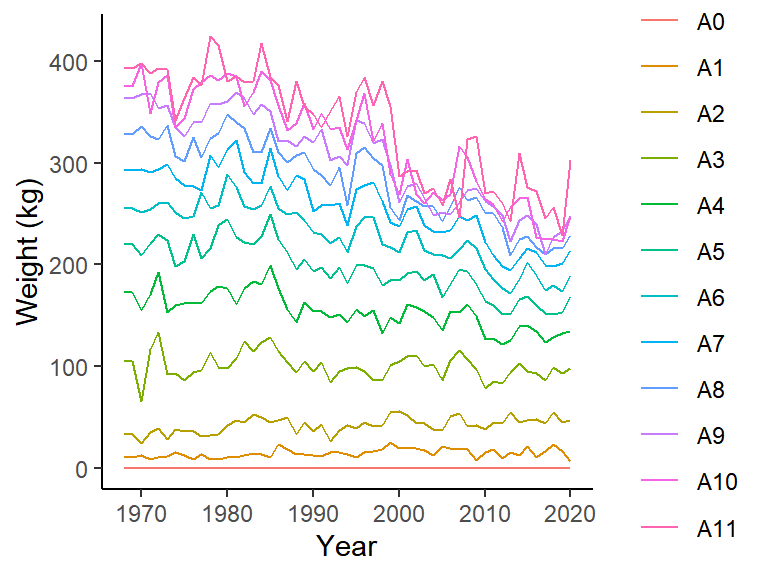

Fig 1.1 Weight-at-age time series

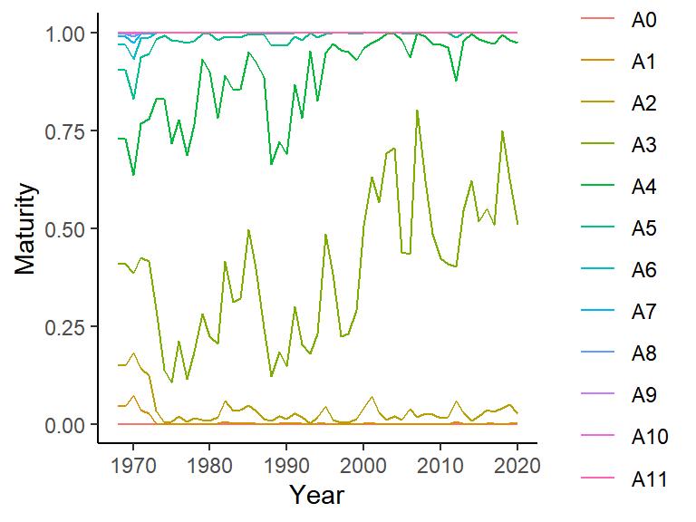

Fig 1.2 Maturity-at-age time series

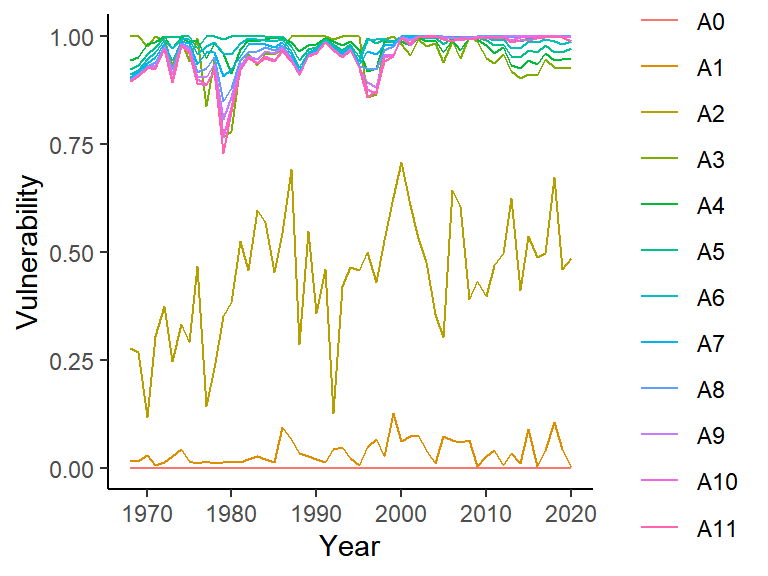

Fig 1.3 Vulnerability-at-age time series

*Note: Selectivity is changing over time due to variable catch percentages by fleet (the 3 fleets have different selectivities)*

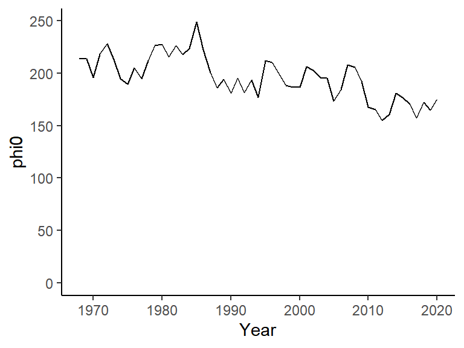

Fig 1.4 Unfished spawning biomass per recruit (phi0) time series

*Note: Calculated using annual weight-at-age, maturity-at-age, and vulnerability-at-age*

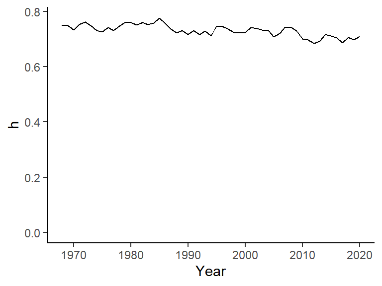

Fig 1.5 Steepness (h) time series

*Note: Steepness is estimated from constant Beverton-Holt a=0.0560481 and annual phi0*

### Model estimated variables

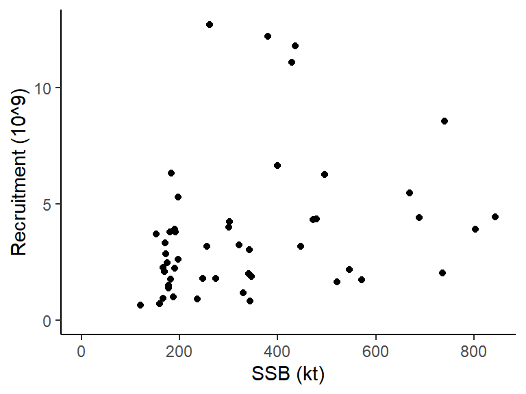

Fig 2.1 Stock recruitment observations

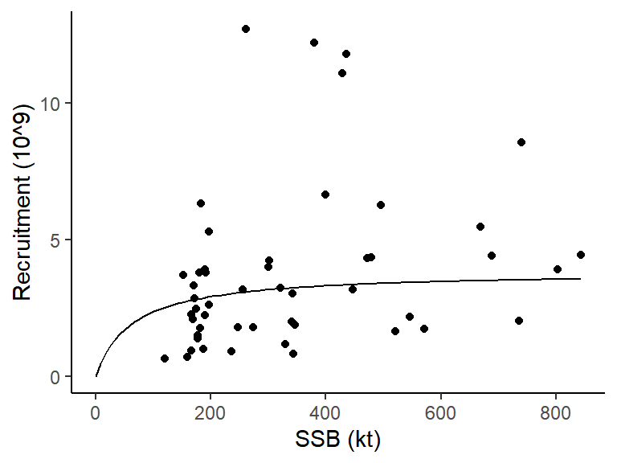

Fig 2.2 Stock recruitment observations with model estimated fit

*Model estimated Beverton-Holt stock recruitment relationship, a = 0.0560481; b = 0.01465815, estimated from assumed h = 0.75 and mean phi0 over the first 5 years of the time series*

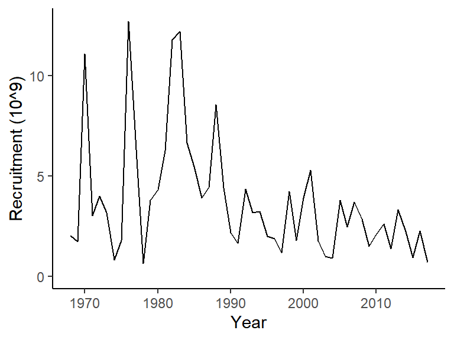

Fig 2.3 Historical recruitment time series

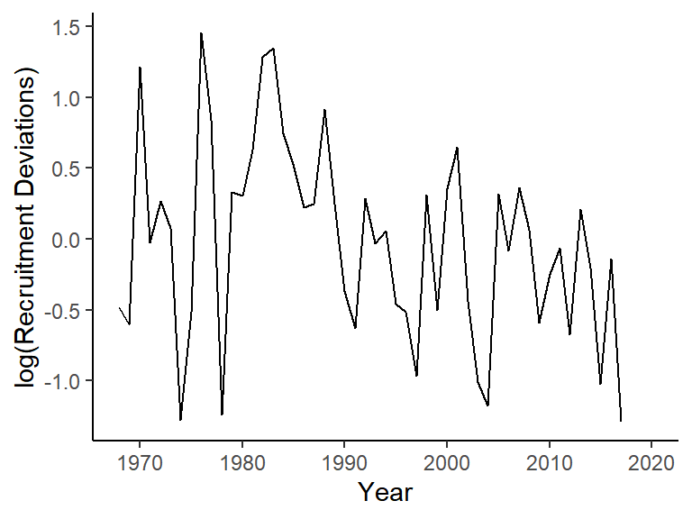

Fig 2.4 Historical recruitment deviations time series

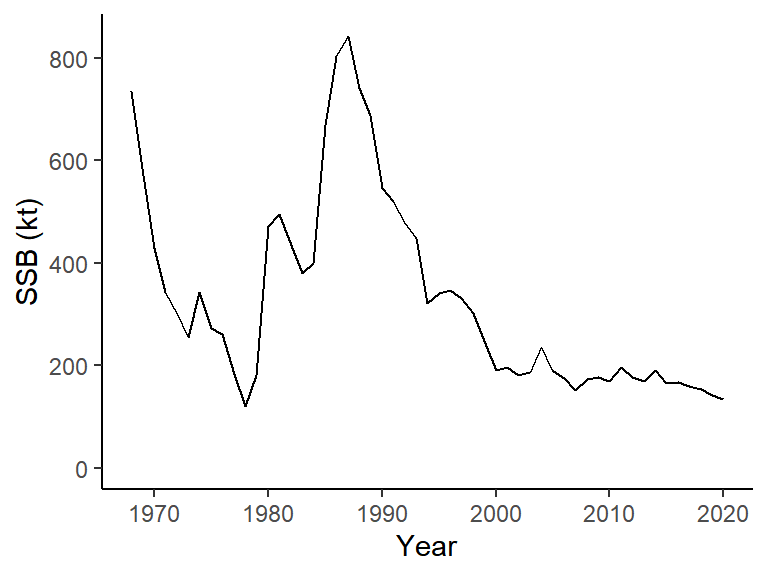

Fig 2.5 Historical SSB time series

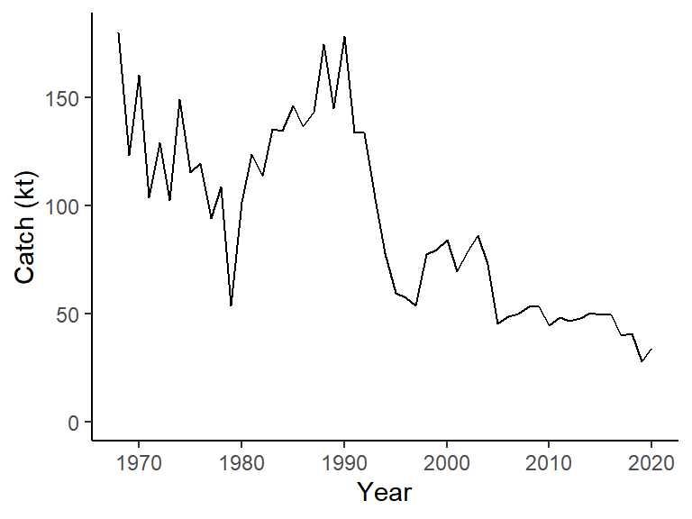

Fig 2.6 Historical Catch time series

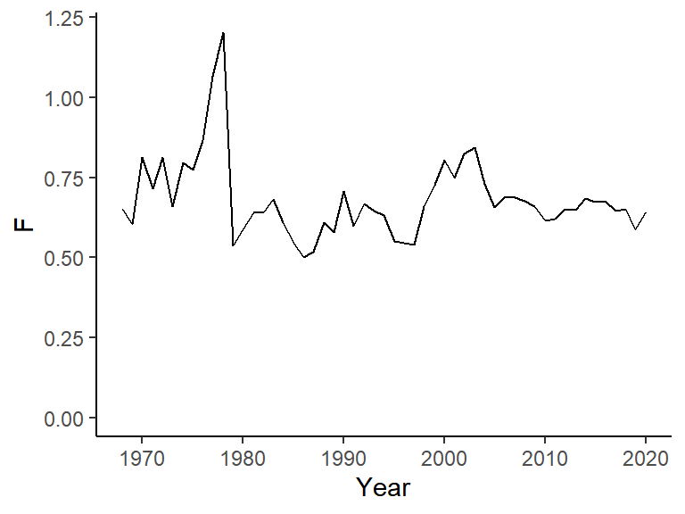

Fig 2.7 Historical F series

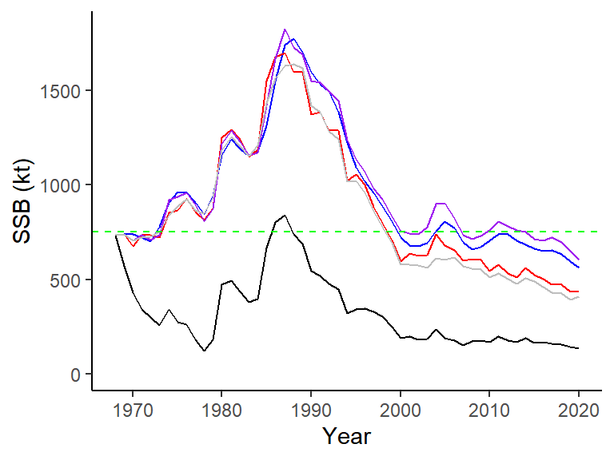

Fig 2.8 Historical SSB time series

*Model estimated SSB as black line*  
*green line = Virgin unfished SSB<sub>0</sub> estimated using mean phi0 over first 5 years*  
*red line = Dynamic SSB<sub>0</sub> estimated using annual recruitment deviations, annual maturity-at-age, annual weight-at-age*  
*purple line = Dynamic SSB<sub>0</sub> estimated using annual recruitment deviations, annual maturity-at-age, mean weight-at-age over first 5 years*  
*grey line = Dynamic SSB<sub>0</sub> estimated using annual recruitment deviations, annual weight-at-age, mean maturity-at-age over first 5 years*  
*blue line = Dynamic SSB<sub>0</sub> estimated using annual recruitment deviations, mean maturity-at-age and mean weight-at-age over first 5 years*

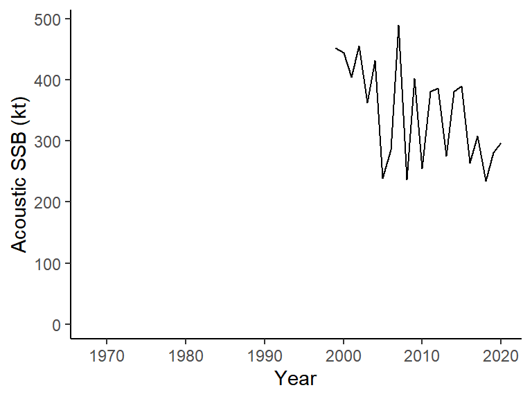

Fig 2.9 Acoustic Index of SSB (1999-2020)

*The index is a relative (not absolute) index of SSB*